# Introducing python classes

and object-oriented programming

```python
class person:
    def __init__(self,name):
        self.name = name
```

```python
a = person("Bob")
print a.name
```

```
Bob
```

What does this behavior remind you of?

Now, let's get our person object something to do

```python
def greet(self):
    print "Hello, my name is %s" % self.name

person.greet = greet

a = person("Alice")
b = person("Marie")
a.greet()
b.greet()
```

```
Hello, my name is Alice
Hello, my name is Marie
```

In object-oriented programming (OOP) *objects*, such as *classes* in Python carry out their own internal computations, and store there own data.

What makes Python an object-oriented language?

# Biology from first principles

First, let's consider an organism with a 'genetic code' of bits

```python
from scipy.stats import bernoulli
class genome:
    """An example of a simple genome"""
    def __init__(self,given_genome=[]):
        """Initialize a genome with a random collection of bits"""
        if len(given_genome) == 0:
            self.info = bernoulli.rvs(.5,size=30)
        else:
            self.info = given_genome
myGenome = genome()
print myGenome.info
```

```
[0 1 0 1 1 0 1 0 0 0 0 0 1 1 0 0 1 1 0 1 0 1 1 1 0 0 0 1 1 1]
```

**Observation:** A genome is copied with some degree of error. We'll write a function that does this, with an error probability *u*

```python
def replicate(self, u = 0):
    errors = bernoulli.rvs(u,size=len(self.info))
    new_genome = []
    for i in range(len(self.info)):
        if errors[i]:
            new_genome.append(int(not self.info[i]))
        else:
            new_genome.append(int(self.info[i]))
    return genome(new_genome)
```

```python
#add new function to old definition
genome.replicate = replicate
myGenome = genome()
newGenome = myGenome.replicate(.1)

#compare old and new genomes
print " ".join(map(str,myGenome.info))
print " ".join([('|' if newGenome.info[i] == myGenome.info[i] else ' ') for i in range(len(newGenome.info))])
print " ".join(map(str,newGenome.info))
```

```
0 0 0 1 1 0 0 0 0 1 1 0 0 0 1 0 1 0 0 0 1 0 0 0 1 0 1 1 0 1
| | | |   | | | | | | | | | | | | | | | | | |     | | | | |
0 0 0 1 0 0 0 0 0 1 1 0 0 0 1 0 1 0 0 0 1 0 0 1 0 0 1 1 0 1
```

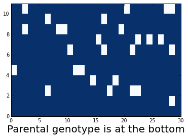

```python
import matplotlib.pyplot as plt
import numpy as np
myGenome = genome(np.array([1]*30))
genomes = np.array(myGenome.info)
for i in range(10):
    genomes = np.vstack([genomes, myGenome.replicate(.1).info ])

%pylab inline
fig, ax = plt.subplots()
ax.set_xlabel('Parental genotype is at the bottom', fontsize=20)
plt.ylim((0,11))
heatmap = ax.pcolor(genomes, cmap=plt.cm.Blues)
```

In the plot above, the original genotype is in blue, while the mutants are in white

## Mutatons are the only source of innovation for life

# What effect does mutation have on relatedness between parents and offspring?

```python
#Let's simulate a parental genome, and offspring genomes
myGenome = genome(np.array([1]*30))
generations = [myGenome.info]
for i in range(6):
    generations = np.vstack([generations,genome(generations[-1]).replicate(.1).info])
```

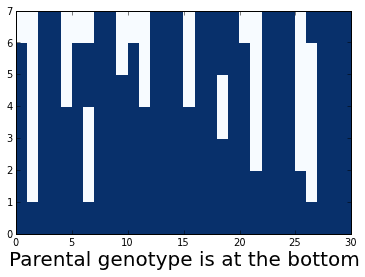

```python
fig, ax = plt.subplots()
ax.set_xlabel('Parental genotype is at the bottom', fontsize=20)
heatmap = ax.pcolor(generations, cmap=plt.cm.Blues)
```

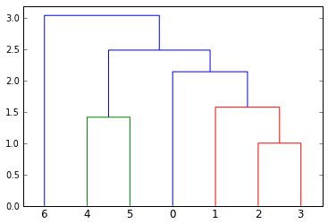

```python
from scipy.cluster.hierarchy import *
from scipy.spatial.distance import pdist

#compute euclidean distance between genomes
distance = pdist(genomes,'euclidean')
#make and plot a UPGMA tree
dendro = dendrogram(average(generations))
```

If generations are labeled from 0 to 6, what does the dendrogram imply about the relationships between the generations?

# Thought experiment

- Let's imagine we have a very long genome
  - So long, that the probability of the same mutation occuring twice at the same location is close to zero
    - by the way, a given location in the genome is called a **locus**
- The population of organisms is finite
- Oranisms are sampled with replacement from one generation to the next
- Mutations are introduced with rate *u*

What is the likelihood of a mutation becoming *fixed* in the population (*i.e.*, to replace all of the ancestral versions).

- by the way, different versions of the same gene are known as **alleles**
- what corresponds to alleles in our toy example?

[figure not shown]

```python
from IPython.core.display import Image
Image(filename='media/fruitfly clock.png')
```

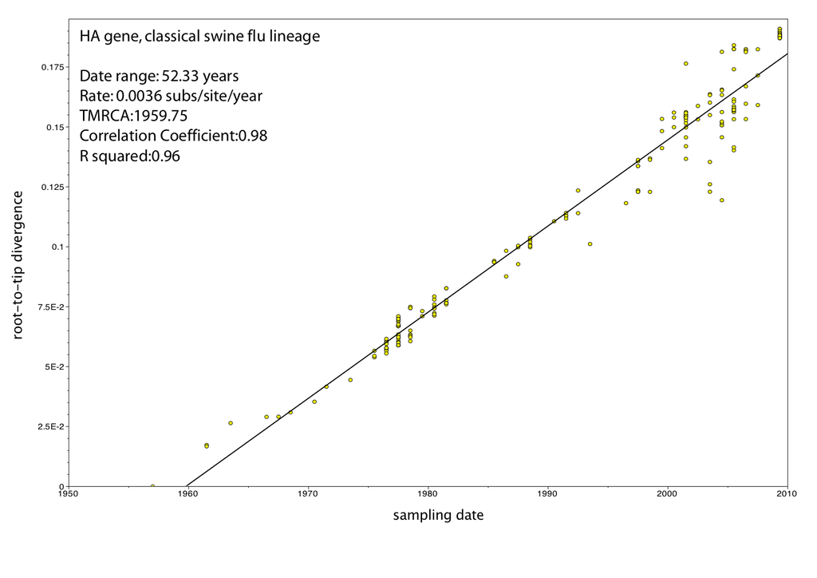

```python
Image(filename='media/swine flu clock.jpg')
```

# Other kinds of genetic alphabets

Using biopython

```python
from Bio.Seq import Seq
from Bio.Alphabet import IUPAC

coding_dna = Seq("ATGGCCATTGTAATGGGCCGCTGAAAGGGTGCCCGATAG", IUPAC.unambiguous_dna)

coding_dna.translate()
```

```
Seq('MAIVMGR*KGAR*', HasStopCodon(IUPACProtein(), '*'))
```

- proteins have much higher information content per character
- however, since three 4-letter nucleotides code for each protein, information is lost in translation
  - You will see this in the "Inferring mRNA from Protein" homework problem
  - The phenomenon that several codons can code for the same protein is know as *degeneracy*

Assuming that the sequence of a protein should be conserved, what are the implications of degeneracy for mutations?